# Part 2: Imputing missing values

Craig Jolley

December 4, 2017

## Loading packages and data

```r
library(dplyr)
library(ggplot2)
library(mice)
library(forcats)
library(haven)
library(knitr)

setwd("C:/Users/Craig/Desktop/Live projects/AI/LAPOP")
my_data <- read.csv('ml_me.csv')
lapop <- read_dta('AmericasBarometer Grand Merge 2004-2014 v3.0_FREE.dta') %>%
  filter(year >= 2012)
```

## Distinguishing numeric and scale variabes

The variables we’re interested in can be separated into two general types. *Scale* variables measure a quantity of something. *Factor* variables describe membership in a category. For example, a survey question that asks about a person’s age or how much they trust the police is asking them to quantify something and should be a numeric variable. A question that asks about a person’s religion or occupation is assigning them to a category, and should be a factor variable.

One difficulty is that both types of variable are recorded as numbers, so we’ll need to make some decisions about which category each variable belongs in. Another is that some of the factor variables (especially the geographic ones) have a very large number of categories, which can complicate things further down the line. We’ll begin by collecting some information about variables and their labels into a data frame.

```r
lvars <- intersect(names(lapop),names(my_data))
codes <- data_frame(var=lvars,
                    label=sapply(lapop[,lvars],function(x) attr(x,'label')),
                    first=unlist(sapply(lapop[,lvars],function(x)
                      names(attr(x,'labels'))[1])),
                    first_val=unlist(sapply(lapop[,lvars],function(x)
                      attr(x,'labels')[1])),
                    second=unlist(sapply(lapop[,lvars],function(x)
                      names(attr(x,'labels'))[2])),
                    second_val=unlist(sapply(lapop[,lvars],function(x)
                      attr(x,'labels')[2])),
                    num_unique=unlist(sapply(lapop[,lvars],function(x)
                      table(x) %>% length)))
kable(codes[1:9,])
```

| var | label | first | first_val | second | second_val | num_unique |
| --- | --- | --- | --- | --- | --- | --- |
| pais | Country | Mexico | 1 | Guatemala | 2 | 22 |
| estratopri | Primary Strata | Norte | 101 | Centro Occidente | 102 | 107 |
| estratosec | Secondary Strata | Large | 1 | Medium | 2 | 5 |
| prov | Province | Aguascalientes | 101 | Baja California | 102 | 336 |
| municipio | Municipio | Tepezal | 101009 | Mexicali | 102002 | 1158 |
| ur | Urban/Rural | Urban | 1 | Rural | 2 | 2 |
| tamano | Size of Location | National Capital (Metropolitan Area) | 1 | Large City | 2 | 5 |
| q1 | Sex | Male | 1 | Female | 2 | 2 |
| q2 | Age | Don’t Know | NA | No Response | NA | 84 |

So, for example, we can see that some variables contain only a few options; `ur` is only answered as Urban/Rural, and q1 is only Male/Female. Age (`q2`) is clearly a numeric scale, with 84 unique responses given to this question. In other cases, such as `municipio`, we have a variable with a large number (1,158) of qualitatively different responses.

This process of deciding which variables are factors and which are a continuous scale involves some judgements. For example, idio2 (Perception of Personal Economic Situation) has three responses: Better, Same, and Worse. Are these three distinct categories, or should they be assigned values on a scale of 1-3?

We can categorize many variables by looking at the text used to describe responses. A few don’t fall into these neat categories and we’ll need to place them in lists by hand.

### Factor variables

Binary variables are those for which only two responses were available

```r
binary <- (codes %>% filter(num_unique==2))$var
codes %>% filter(var %in% binary) %>% select(var,label,first,second) %>%
  kable
```

| var | label | first | second |
| --- | --- | --- | --- |
| ur | Urban/Rural | Urban | Rural |
| q1 | Sex | Male | Female |
| exc2 | Police Officer Asked for a Bribe | No | Yes |
| exc6 | Government Employee Asked for a Bribe | No | Yes |
| gi4 | Knowledge - Length of Term for President/Prime Minister/Government | Correct | Incorrect |
| prot3 | Participated in a Protest | Yes | No |
| q10a | Receives Remittances | Yes | No |
| q14 | Intends to Live or Work Abroad | Yes | No |
| sex | Sex | Male | Female |
| vb2 | Voted in Presidential Election | Voted | Did Not Vote |
| vb10 | Identifies with a Political Party | Yes | No |
| vic1ext | Victim of Crime in the Last 12 Months | Yes | No |
| vic1hogar | Other Household Member Was a Victim of Crime | Yes | No |
| vic44 | Organized in Neighborhood for Security | No | Yes |

For some other factor variables, a small number of qualitatively-different responses were available.

```r
other_factor <- c('estratosec','tamano','aoj22','dem2','idio2','ocup4a','q10d',
                  'q10e','soct2','vb1')
codes %>% filter(var %in% other_factor) %>% select(var,num_unique,label) %>%
  kable
```

| var | num_unique | label |
| --- | --- | --- |
| estratosec | 5 | Secondary Strata |
| tamano | 5 | Size of Location |
| aoj22 | 3 | How to Reduce Crime |
| dem2 | 3 | Perception of Democracy |
| idio2 | 3 | Perception of Personal Economic Situation |
| ocup4a | 7 | Employment Status |
| q10d | 4 | Family Economic Situation |
| q10e | 3 | Household Income Over Last Two Years |
| soct2 | 3 | Evaluation of the Economic Situation of the Country |
| vb1 | 3 | Registered to Vote |

A few factor variables involved a large number of possible responses; we’ll need to handle those differently.

```r
big_factor <- c('pais','estratopri','prov','municipio','etid','leng1','q3c')
codes %>% filter(var %in% big_factor) %>%
  select(var,num_unique,label,first) %>% kable
```

| var | num_unique | label | first |
| --- | --- | --- | --- |
| pais | 22 | Country | Mexico |
| estratopri | 107 | Primary Strata | Norte |
| prov | 336 | Province | Aguascalientes |
| municipio | 1158 | Municipio | Tepezal |
| etid | 36 | Ethnicity | White |
| leng1 | 120 | Mother Tongue | Espaol/castellano |
| q3c | 13 | Religion | Catholic |

### Scale variables

Often, we could spot scale variables based on key words that denote one end of a scale of values.

```r
scale <- (codes %>% filter(grepl(paste0('Strong|Very|(A Lot)|(Not at All)|',
             '(Once a Week)|Daily|None'),first)))$var
codes %>% filter(var %in% scale) %>% select(var,label,num_unique,first) %>%
  kable
```

| var | label | num_unique | first |
| --- | --- | --- | --- |
| aoj11 | Perception of Neighborhood Insecurity | 4 | Very Safe |
| aoj12 | Confidence that Judiciary will Punish the Guilty | 4 | A Lot |
| aoj17 | Gang Presence in Neighborhood | 4 | A Lot |
| b1 | Courts Guarantee Fair Trial | 7 | Not at All |
| b2 | Respect for Political Institutions | 7 | Not at All |
| b3 | Basic Rights are Protected | 7 | Not at All |
| b4 | Pride in Political System | 7 | Not at All |
| b6 | People Should Support the Political System | 7 | Not at All |
| b10a | Trust in Judicial System | 7 | Not at All |
| b13 | Trust in the National Legislature | 7 | Not at All |
| b18 | Trust in National Police | 7 | Not at All |
| cp5 | Helped Solve a Problem in the Community | 4 | Once a Week |
| cp6 | Attendance at Meetings of Religious Organization | 4 | Once a Week |
| cp7 | Attendance at Meetings of Parent Association | 4 | Once a Week |
| cp8 | Attendance at Meetings of Community Improvement Group | 4 | Once a Week |
| d1 | Approval of Government Critics’ Right to Vote | 10 | Strongly Disapprove |
| d2 | Approval of Government Critics’ Right to Peaceful Demonstrations | 10 | Strongly Disapprove |
| d3 | Approval of Government Critics’ Right to Run for Office | 10 | Strongly Disapprove |
| d4 | Approval of Government Critics’ Right to Make Speeches | 10 | Strongly Disapprove |
| d5 | Approval of Homosexuals’ Right to Run for Office | 10 | Strongly Disapprove |
| e3 | Approval of Groups Attempting to Overthrow Elected Government | 10 | Strongly Disapprove |
| e5 | Approval of Those Participating in Legal Demonstration | 10 | Strongly Disapprove |
| e15 | Approval of Those Blocking Roads to Protest | 10 | Strongly Disapprove |
| e16 | Approval of Vigilante Justice | 10 | Strongly Disapprove |
| ed | Years of Schooling | 19 | None |
| eff1 | Leaders Are Interested in What People Think | 7 | Strongly Disagree |
| eff2 | Understands Important Political Issues | 7 | Strongly Disagree |
| gi0 | Frequency of Paying Attention to the News | 5 | Daily |
| ing4 | Democracy is Better than Any Other Form of Government | 7 | Strongly Disagree |
| it1 | Interpersonal Trust | 4 | Very Trustworthy |
| ls3 | Life Satisfaction | 4 | Very Satisfied |
| m1 | Executive Job Approval | 5 | Very Good |
| n11 | Evaluation of Administration’s Handling of Citizen Security | 7 | Not at All |
| n15 | Evaluation of Administration’s Handling of Economy | 7 | Not at All |
| pol1 | Political Interest | 4 | A Lot |
| q5b | Importance of Religion | 4 | Very Important |
| q12 | Number of Children | 26 | None |
| sd2new2 | Satisfaction with Roads | 4 | Very Satisfied |
| sd3new2 | Satisfaction with Public Schools | 4 | Very Satisfied |
| sd6new2 | Satisfaction with Public Medical and Health Services | 4 | Very Satisfied |
| www1 | Internet Usage | 5 | Daily |

There were a few other scale variables as well.

```r
other_scale <- c('q2','colorr','q12c')
codes %>% filter(var %in% other_scale) %>% select(var,label,num_unique,first,second) %>% kable
```

| var | label | num_unique | first | second |
| --- | --- | --- | --- | --- |
| q2 | Age | 84 | Don’t Know | No Response |
| colorr | Skin Color | 11 | very light | very dark |
| q12c | Number of People in Household | 35 | Don’t Know | No Response |

Note that, in the case of `q2` (age) and `q12c` (number of people in household), all of the valid responses are numbers. This means that the first *labeled* response is “Don’t know”, which gets coded as a missing response, rather than as a number.

We can now label our factor variables as such:

```r
for (f in c(binary,other_factor,big_factor)) {
  my_data[,f] <- as.factor(my_data[,f])
}
```

## Simplifying factor variables

Before we can use these data as inputs for a machine learning algorithm, we’ll need to deal with missing data. Here are some of the variables that are missing most frequently.

```r
codes$missing <- sapply(codes$var, function(x) my_data[,x] %>% is.na %>% mean)
codes %>% arrange(desc(missing)) %>% select(var,label,missing,num_unique) %>%
  head %>% kable
```

| var | label | missing | num_unique |
| --- | --- | --- | --- |
| dem2 | Perception of Democracy | 0.0797738 | 3 |
| gi4 | Knowledge - Length of Term for President/Prime Minister/Government | 0.0744075 | 2 |
| sd3new2 | Satisfaction with Public Schools | 0.0685651 | 4 |
| ing4 | Democracy is Better than Any Other Form of Government | 0.0518602 | 7 |
| q10e | Household Income Over Last Two Years | 0.0499560 | 3 |
| q10d | Family Economic Situation | 0.0460467 | 4 |

One thing that will be tricky here is that imputation algorithms generally don’t work well with factor variables that have a very large number of categories. If you have a lot of categories, you only have a small number in each category. When this happens, it’s hard for the algorithm to learn enough about the characteristics of a category to assign anything to it with much reliability. We’ll need to aggregate some of these factor variables with lots of levels into something simpler. Which factor variables are problems?

```r
codes %>% filter(var %in% big_factor) %>%
  select(var,num_unique,missing) %>% arrange(desc(missing)) %>% head %>%
  kable
```

| var | num_unique | missing |
| --- | --- | --- |
| q3c | 13 | 0.0247688 |
| etid | 36 | 0.0198064 |
| leng1 | 120 | 0.0046162 |
| pais | 22 | 0.0000000 |
| estratopri | 107 | 0.0000000 |
| prov | 336 | 0.0000000 |

We need to make judgement calls about which languages, ethnicities, or religions are similar enough that they can be lumped together, or minor enough to be grouped into an “Other” category.

```r
leng1_labels <- attr(lapop[['leng1']],'labels')
```

This is complicated further by the fact that the same language appears under several different codes, based on the country survey. For example, Spanish appears in 14 different places on the list.

```r
leng1_labels[which(names(leng1_labels)=='Spanish')]
```

```
Spanish Spanish Spanish Spanish Spanish Spanish Spanish Spanish Spanish
    201     301     401     601     701     801    1001    1301    1601
Spanish Spanish Spanish Spanish Spanish
   2101    2203    2503    2610    2801
```

To address this, we’ll lump different languages together by searching through the text labels, rather than relying on the numbers. There’s a small catch, though – not all the same options were presented in each country. For example, let’s look at which countries used a label for Chinese in `leng1`:

```r
pais_labels <- data.frame(country_name=names(attr(lapop[['pais']],'labels')),
                          pais=attr(lapop[['pais']],'labels') %>% as.factor)
my_data %>% filter(leng1 %in% leng1_labels[which(names(leng1_labels)=='Chinese')]) %>%
  select(leng1,pais) %>% unique %>%
  left_join(pais_labels) %>%
  kable
```

| leng1 | pais | country_name |
| --- | --- | --- |
| 2601 | 26 | Belize |
| 2403 | 24 | Guyana |
| 2710 | 27 | Suriname |
| 2504 | 25 | Trinidad and Tobago |

If we took the survey results at face value, we would conclude that *all* the Chinese speakers in Latin America live in these four countries. This is unlikely to be true; it is more likely that any Chinese speakers in other countries got lumped into an “Other” category, possibly along with speakers of Hindi, Dutch and German. In other countries however, speakers of those languages got their own categories. As a result, we’ll end up focusing on a small number of widely-spoken languages, where survey design would have been more consistent across the region.

It’s also possible to look at this in the other direction, to see (for example), which language responses were available for survey-takers in Mexico:

```r
leng1_df <- data.frame(lang_name=names(leng1_labels),
                       leng1=as.factor(leng1_labels))
pais_labels %>% filter(country_name=='Mexico') %>%
  left_join(my_data %>% select(pais,leng1) %>% unique,by='pais') %>%
  left_join(leng1_df,by='leng1') %>%
  arrange(leng1) %>%
  kable
```

| country_name | pais | leng1 | lang_name |
| --- | --- | --- | --- |
| Mexico | 1 | 101 | Espaol/castellano |
| Mexico | 1 | 102 | Nhuatl |
| Mexico | 1 | 103 | Maya |
| Mexico | 1 | 104 | Other (indigenous) |
| Mexico | 1 | 105 | Other (foreign) |
| Mexico | 1 | 106 | Zapoteca |
| Mexico | 1 | 107 | Mixteca |
| Mexico | 1 | NA | Don’t Know |
| Mexico | 1 | NA | No Response |
| Mexico | 1 | NA | Not Applicable |
| Mexico | 1 | NA | Not asked in this country or year |

Note that R’s character encodings (with their bias toward English) mangled Español and Náhuatl to Espaol and Nhuatl.

We’ll take the 154 language labels present in the dataset and condense them into a few groups: Spanish, English, Portugese, Creole, Indigenous, and Other. Note that the analyst’s Anglophone bias is already showing through here – English may not actually seem so important to someone who isn’t based in the U.S. More significantly, the speakers of languages referred to as “Creole” in Haiti, Belize, Barbados and the Bahamas may not agree that they all speak the same language, or that Jamaican Patois belongs in the same group. Similarly, “indigenous” is a very broad category, including languages such as Garifuna with significant non-indigenous influences.

```r
spanish <- leng1_labels[grep('Spanish|astellano',names(leng1_labels))] %>% as.character
foreign <- leng1_labels[grep(paste0('oreign|Chinese|Hindi|Javanese|Dutch|',
  'German|French|^Other$'),names(leng1_labels))] %>% as.character
english <- leng1_labels[grep('^English',names(leng1_labels))] %>% as.character
portuguese <- leng1_labels[grep('Portuguese',names(leng1_labels))] %>%
  as.character
creole <- leng1_labels[grep('Creole|Criollo|Patois',names(leng1_labels))] %>%
  as.character
bad <- leng1_labels[grep('No|Don\'t',names(leng1_labels))] %>% as.character
indig <- leng1_labels %>%
  as.character %>%
  setdiff(c(spanish,foreign,english,portuguese,creole,bad))
```

There are 50 unique language labels in our “indigenous” category:

```r
leng1_labels[as.character(leng1_labels) %in% indig] %>% names %>% unique
```

```
 [1] "N<e1>huatl"
 [2] "Maya"
 [3] "Other (indigenous)"
 [4] "Zapoteca"
 [5] "Mixteca"
 [6] "Mam"
 [7] "Kiche"
 [8] "Kaqchiquel"
 [9] "Qeqchi"
[10] "Lenca"
[11] "Gar<ed>funa"
[12] "Misquito"
[13] "Xicaque"
[14] "Paya"
[15] "M<ed>skito"
```

[output cut: 35 more lines]

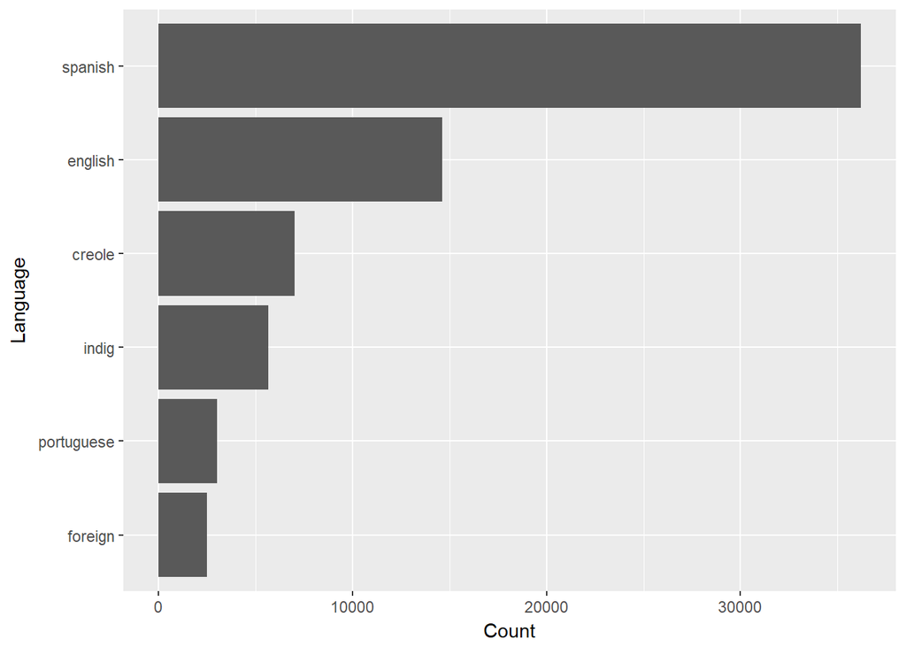

```r
my_data$leng1 <- fct_collapse(my_data$leng1,
                              spanish=spanish,
                              foreign=foreign,
                              english=english,
                              portuguese=portuguese,
                              creole=creole,
                              indig=indig)
rm(spanish,foreign,english,portuguese,creole,bad,indig,leng1_labels)
table(my_data$leng1) %>% as.data.frame %>%
  ggplot(aes(x=fct_reorder(Var1,Freq),y=Freq)) +
    geom_bar(stat='identity') +
    xlab('Language') + ylab('Count') +
    coord_flip()
```

```r
# TODO: I know there's a way to make this prettier with forcats, but I need
# internet to look it up
```

It might be a little surprising that English ranked as having almost half as many speakers as Spanish. We can understand this a little better by looking at the number of survey responses from each country.

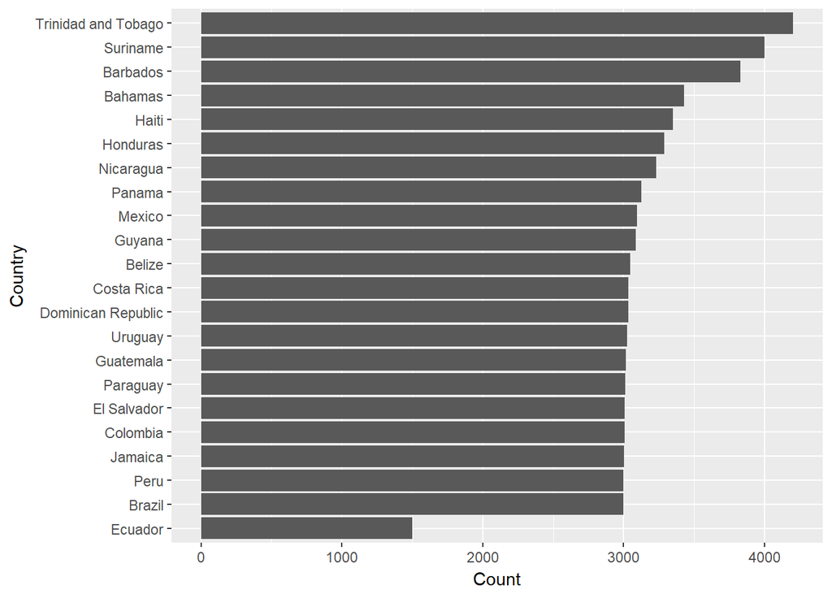

```r
table(my_data$pais) %>% as.data.frame %>%
  rename(pais=Var1) %>% left_join(pais_labels,by='pais') %>%
  mutate(country_name=as.character(country_name),
         country_name=ifelse(grepl('Hait',country_name),
                             'Haiti',country_name)) %>%
  ggplot(aes(x=fct_reorder(country_name,Freq),y=Freq)) +
    geom_bar(stat='identity') +
    xlab('Country') + ylab('Count') +
    coord_flip()
```

Most countries have a roughly-similar number of responses, with larger samples coming froma few small Caribbean nations. This means that small English-speaking countries like Jamaica or Barbados are dramatically over-represented relative to much more populous Spanish-speaking countries like Mexico and Colombia. When we are simply taking averages, this can be corrected easily by reweighting the individuals that are representative of larger populations. Similar reweighting can be more challenging with some machine-learning models, and may lead to models that are more accurate in countries with smaller populations.

We need to do some similar categorization with the `etid` (ethnicity) variable. The categories below seem plausible enough, but imposing a small number of ethnic labels on the Latin American melting pot is always going to be a challenge. The choices we’ve made here almost certainly reflect the point of view of North Americans with very limited knowledge of Latin American or Caribbean cultures, and members of the groups being categorized would likely take issue with some of the choices. There’s no way to get around this without actually going out and talking to people from the affected groups and getting their input on which classifications make sense in context.

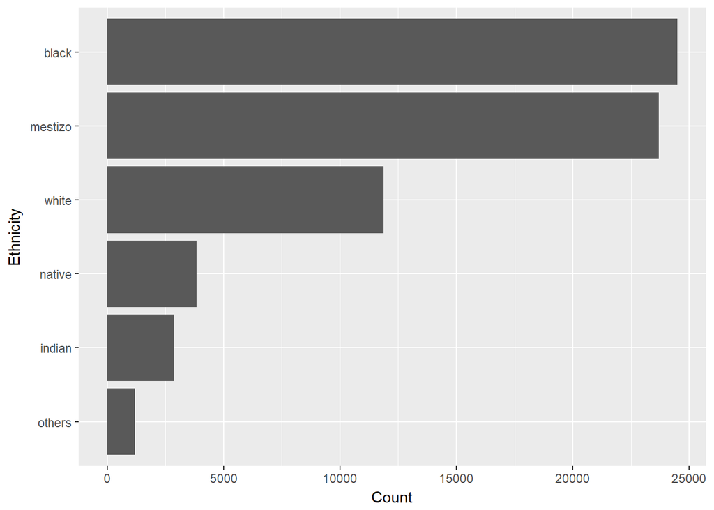

```r
etid_labels <- attr(lapop[['etid']],'labels')
mestizo <- etid_labels[grep('Mestizo',names(etid_labels))] %>% as.character
indian <- etid_labels[grep('Indian|Indo',names(etid_labels))] %>% as.character
white <- etid_labels[grep('White|Spanish|Jews|Mennonite|Portuguese',
                          names(etid_labels))] %>% as.character
black <- etid_labels[grep('Black|Afro|Mullatto|Garifuna|Maroon|Creole|Moreno'
                          ,names(etid_labels))] %>% as.character
native <- etid_labels[grep('Indigenous|Quechua|Aymara|Amazon|Zamba|Maya',
                           names(etid_labels))] %>% as.character
others <- etid_labels[grep('Other|Javanese|Syrian|Chinese|Oriental|Yellow',
                           names(etid_labels))] %>% as.character
bad <- etid_labels[grep('^No|^Don\'t',names(etid_labels))] %>% as.character
my_data$etid <- fct_collapse(my_data$etid,
                             mestizo=mestizo,
                             indian=indian,
                             white=white,
                             black=black,
                             native=native,
                             others=others)
rm(etid_labels,mestizo,indian,white,black,native,others,bad)
table(my_data$etid) %>% as.data.frame %>%
  ggplot(aes(x=fct_reorder(Var1,Freq),y=Freq)) +
  geom_bar(stat='identity') +
  xlab('Ethnicity') + ylab('Count') +
  coord_flip()
```

The very large population categorized as “Black” seems surprising, until we consider the overrepresentation of small English-speaking Caribbean nations that was noted above.

Now for `q3c` (religion). As before, this requires some value judgements to be made by the analyst. Members of the “Other” category might chafe at being lumped together, and the mainline/evangelical distinction might matter more in Protestant-influenced North America than in Latin America.

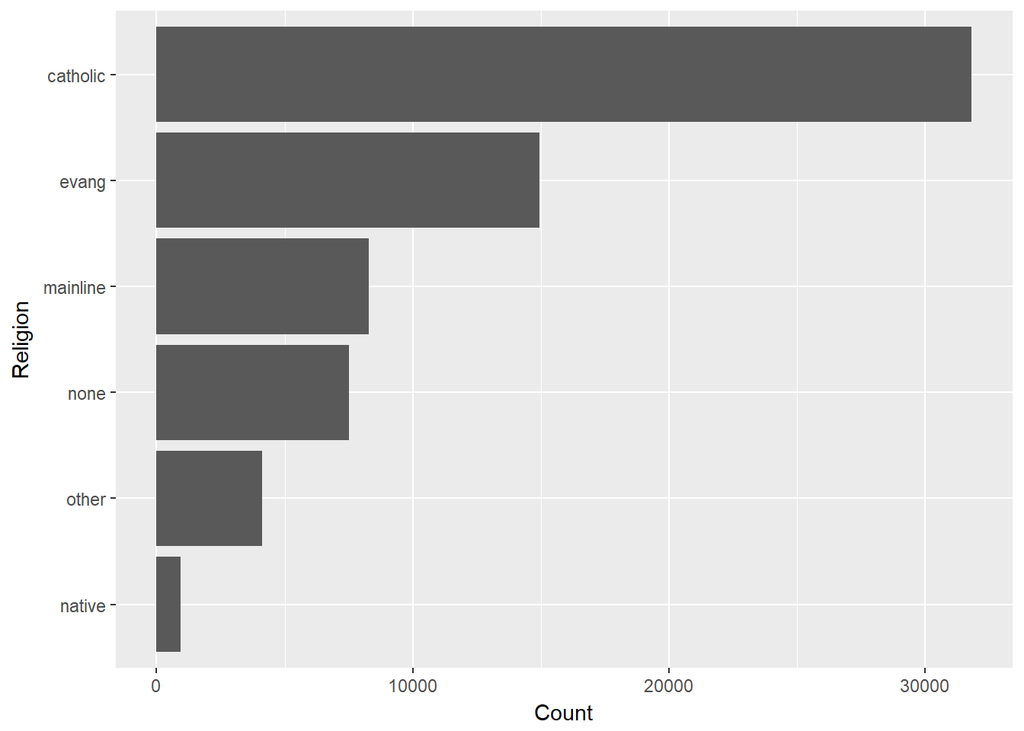

```r
q3c_labels <- attr(lapop[['q3c']],'labels')
catholic <- q3c_labels[grep('Catholic',names(q3c_labels))] %>% as.character
mainline <- q3c_labels[grep('Mainline',names(q3c_labels))] %>% as.character
evang <- q3c_labels[grep('^Evangelical',names(q3c_labels))] %>% as.character
native <- q3c_labels[grep('Native',names(q3c_labels))] %>% as.character
other <- q3c_labels[grep(paste0('Mormon|Jehovah|Orthodox|Eastern|Kardecian|',
   'Muslim|Hindu|Other'),names(q3c_labels))] %>% as.character
none <- q3c_labels[grep('None|Atheist',names(q3c_labels))] %>% as.character
my_data$q3c <- fct_collapse(my_data$q3c,
                            catholic=catholic,
                            mainline=mainline,
                            evang=evang,
                            native=native,
                            other=other,
                            none=none)
rm(catholic,mainline,evang,native,other,none,q3c_labels)
table(my_data$q3c) %>% as.data.frame %>%
  ggplot(aes(x=fct_reorder(Var1,Freq),y=Freq)) +
  geom_bar(stat='identity') +
  xlab('Religion') + ylab('Count') +
  coord_flip()
```

## Imputation

Before imputing, we’ll want to remove some variables that aren’t helping us. As you might have noticed, the `q1` and `sex` variables measure the exact same thing, so we can drop one of them. Let’s also remove `estratopri` and `estratosec`, since the relevant geographic data is already captured by `prov` and `municipio`.

```r
my_data <- my_data %>% select(-q1,-estratopri,-estratosec)
```

When we impute missing values, it would be cheating if we used information from our wealth-related variables. (This is an example of what is sometimes referred to as “data snooping” and can lead to poorly-performing models.) We should also remove `prov` and `municipio` during imputation, because those are factor variables with lots of levels. They tend to slow things down dramatically and cause imputation to use a lot more memory. We’ll want to add these back in later, so we’re creating a new data frame (`x`) that we’ll use only for imputation.

```r
x <- select(my_data,-w_scaled,-w_unscaled,-prov,-municipio)
```

Because we’re imputing a lot of variables on a fairly large dataset, we should benchmark on smaller subsets of it to test how long things will take and make sure our computational resources are adequate. Many algorithms have performance that is roughly polynomial, and we can approximate the benchmarking curve using a power-law function. This should give us a rough estimate of whether imputation of the full dataset will take minutes or years; if the wait time is unacceptably long, we may need to remove more variables.

```r
bench <- function(n) {
  set.seed(12345)
  just_n <- x[sample(nrow(x),n),] %>% droplevels
  ti <- Sys.time()
  imp <- mice(just_n,m=1,printFlag=FALSE,seed=12345)
  tf <- Sys.time()
  difftime(tf,ti,units='secs')
}

n <- c(200,500,1000,2000)
b <- sapply(n,bench)
d <- data.frame(log_n=log(n),log_b=log(b))
b_lm <- lm(log_b ~ log_n,data=d)
p <- predict(b_lm,newdata=data.frame(log_n=log(nrow(x)),log_b=NA))
print(exp(p)/60)
```

```
       1
23.40664
```

Based on benchmarking with subsets of 200, 500, 1000, and 2000 rows, the full dataset should take about 23.4066363 minutes to impute. How long does it take in reality?

```r
# I commented these rows out because it takes an annoying long time; for now I'm just
# loading the saved result of having done this once. When I'm ready to make the final
# version of this I'll uncomment so it's pretty.
# ti <- Sys.time()
# imp <- mice(x,m=1,printFlag=T,seed=12345)
# print(Sys.time()-ti)
# save(imp,file='imp.rda')
load(file='imp.rda')
```

It took about 84 minutes for 69,321 rows.

## Wrapping up

We’ll combine the imputed data with the variables that weren’t part of the imputation (`prov`,`municipio`, and the wealth indices). In addition, we’ll want categorical variables to describe whether responses fall within the poorest 10% of the overall population.

```r
w_imp <- complete(imp,1) %>%
  cbind(my_data[setdiff(names(my_data),names(x))]) %>%
  mutate(poor_unscaled=(w_unscaled <= quantile(w_unscaled,0.1)),
         poor_scaled=(w_scaled <= quantile(w_scaled,0.1)))
```

Rather than saving our results as a CSV file, we’ll save them in a binary format. That way we keep our factor variable assignments for future use.

```r
save(w_imp,file='w_imp.rda')
```